# PCA_OLS

Wu Fuheng

Sunday, November 02, 2014

Over at stats.stackexchange.com recently, a really interesting question was raised about principal component analysis (PCA). The gist was “Thanks to my college class I can do the math, but what does it MEAN?”

I felt like this a number of times in my life. Many of my classes were focused on the technical implementations they kinda missed the section titled “Why I give a shit.” A perfect example was my Mathematics Principles of Economics class which taught me how to manually calculate a bordered Hessian but, for the life of me, I have no idea why I would ever want to calculate such a monster. OK, that’s a lie. Later in life I learned that bordered Hessian matrices are a second derivative test used in some optimizations. Not that I would EVER do that shit by hand. I’d use some R package and blindly trust that it was coded properly.

So back to PCA: as I was reading the aforementioned stats question I was reminded of a recent presentation that Paul Teetor gave at a August Chicago R User Group. In his presentation on spread trading with R he showed a graphic that illustrated the difference between OLS and PCA. I took some notes and went home and made sure I could recreate the same thing. If you have wondered what makes OLS and PCA different, open up an R session and play along.

**Your Independent Variable Matters:**

The first observation to make is that regressing x ~ y is not the same as y ~ x even in a simple univariate regression. You can illustrate this by doing the following:

```r
set.seed(2)
x <- 1:100
y <- 20 + 3 * x
e <- rnorm(100, 0, 60)
y <- 20 + 3 * x + e
```

You should get something that looks like this:

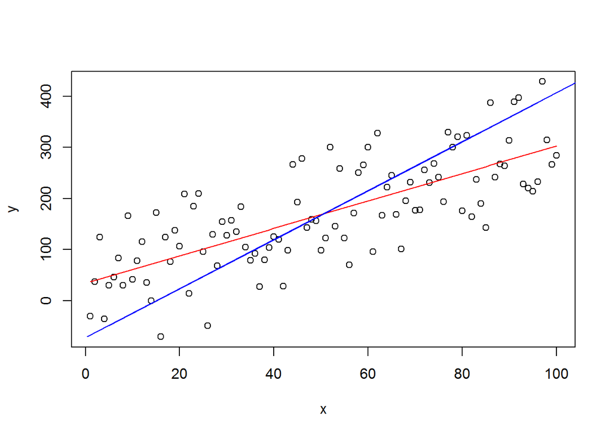

```r
plot(x,y)
yx.lm <- lm(y ~ x)
lines(x, predict(yx.lm), col="red")

xy.lm <- lm(x ~ y)
lines(predict(xy.lm), y, col="blue")
```

So it’s obvious they give different lines. But why? Well, OLS minimizes the error between the dependent and the model. Two of these errors are illustrated for the y ~ x case in the following picture:

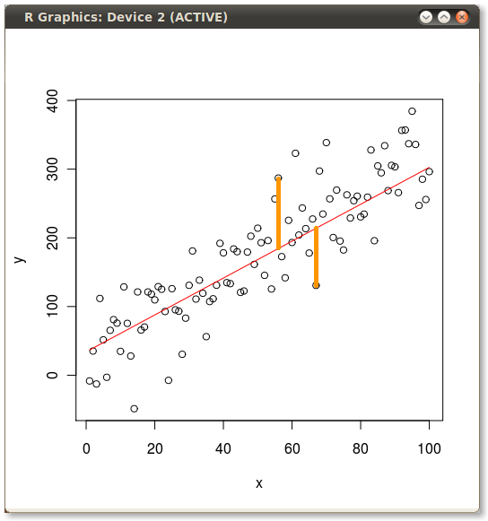

[figure not shown]

Ok, so what about PCA?

Well let’s draw the first principal component the old school way:

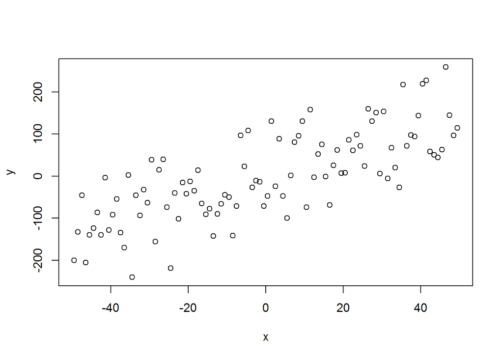

```r
#normalize means and cbind together
xmean=mean(x)
ymean=mean(y)
xyNorm <- cbind(x=x-xmean, y=y-ymean)
plot(xyNorm)
```

```r
#covariance
xyCov <- cov(xyNorm)
eigenValues <- eigen(xyCov)$values
eigenVectors <- eigen(xyCov)$vectors
eigenValues
```

```
## [1] 11318.6564   354.1329
```

```r
eigenVectors
```

```
##           [,1]       [,2]
## [1,] 0.2108664 -0.9775149
## [2,] 0.9775149  0.2108664
```

PCA minimizes the error orthogonal (perpendicular) to the model line. So first principal component looks like this:

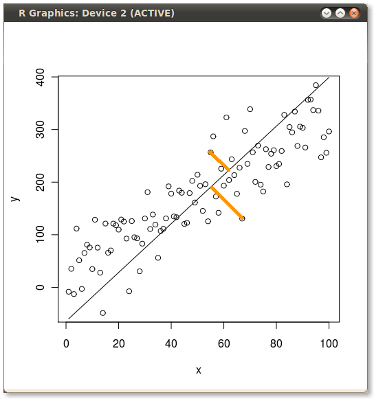

The two yellow lines, as in the previous images, examples of two of the errors which the routine minimizes.

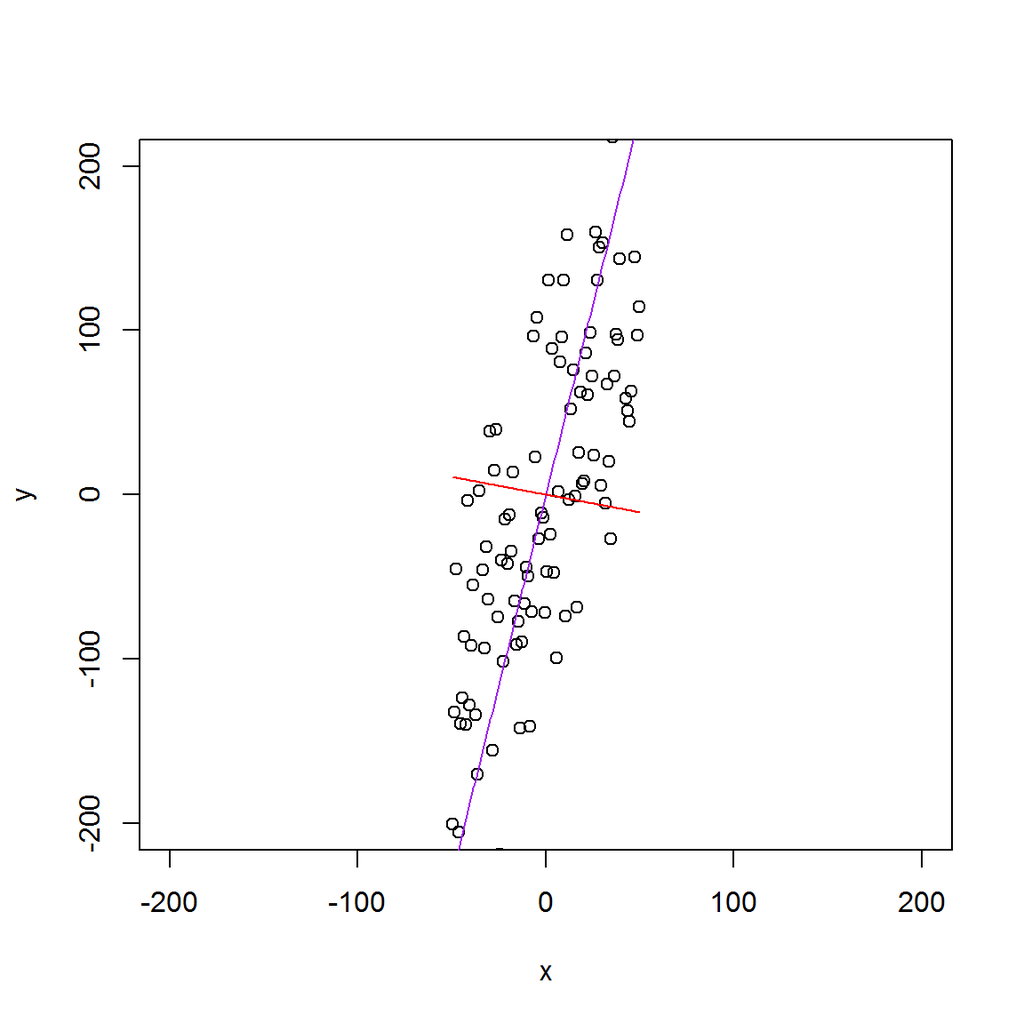

```r
#plot(xyNorm) #, ylim=c(-200,200), xlim=c(-100,100)
plot(xyNorm, ylim=c(-200,200), xlim=c(-200,200))
lines(xyNorm[x], eigenVectors[2,1]/eigenVectors[1,1] * xyNorm[x], col='purple')
lines(xyNorm[x], eigenVectors[2,2]/eigenVectors[1,2] * xyNorm[x], col='red')
```

```r
# the two PCAs are perpendicular
(atan(eigenVectors[2,1]/eigenVectors[1,1]) - atan(eigenVectors[2,2]/eigenVectors[1,2]))*180/pi
```

```
## [1] 90
```

```r
eigenVectors[,1] %*% eigenVectors[,2]
```

```
##      [,1]
## [1,]    0
```

The x ~ y OLS and the first principal component are pretty close, but not exactly the same.

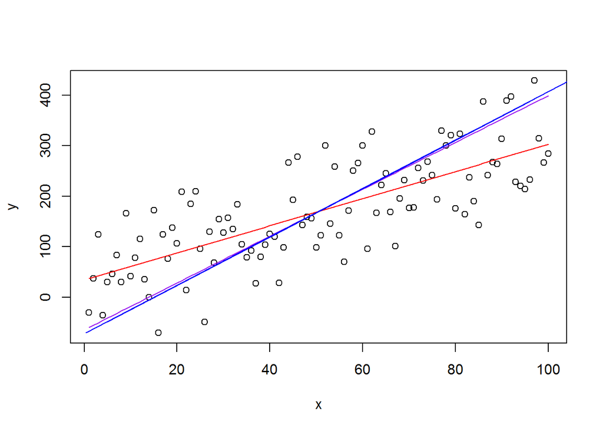

```r
# the largest eigenValue is the first one
# so that’s our principal component.
# but the principal component is in normalized terms (mean=0)
# and we want it back in real terms like our starting data
# so let’s denormalize it
plot(x,y)
lines(x, (eigenVectors[2,1]/eigenVectors[1,1] * xyNorm[x]) + mean(y), col='purple')
# that looks right. line through the middle as expected

# what if we bring back our other two regressions?
lines(x, predict(yx.lm), col="red")
lines(predict(xy.lm), y, col="blue")
```

And the final data is:

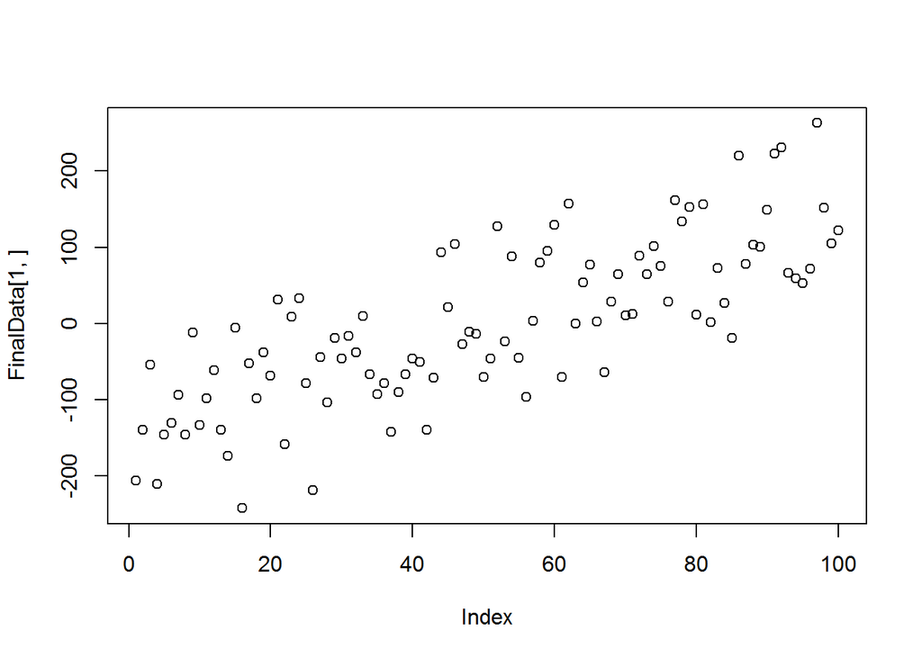

```r
FinalData = t(eigenVectors[,1]) %*% t(xyNorm)
#Final Data After dimension reduction
plot(FinalData[1,])
```

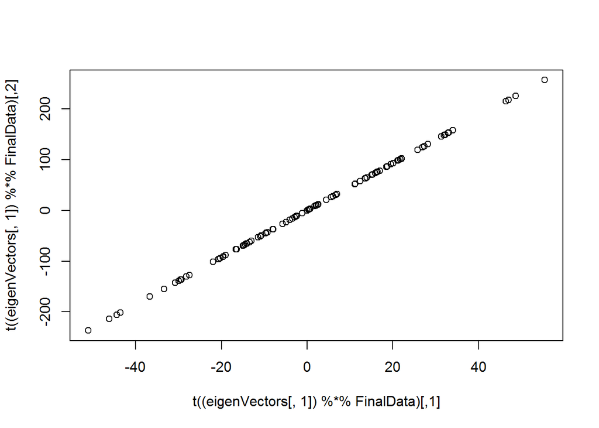

```r
#Trying to get databack but the retrived data have lost some info
plot(t((eigenVectors[,1]) %*% FinalData))
```

```r
FinalData2 = t(eigenVectors) %*% t(xyNorm)
head(t((eigenVectors) %*% FinalData2))
```

```
##       [,1]       [,2]
## [1,] -49.5 -200.47298
## [2,] -48.5 -132.56716
## [3,] -47.5  -45.38739
## [4,] -46.5 -205.48065
## [5,] -45.5 -139.47322
## [6,] -44.5 -123.71289
```

```r
head(xyNorm)
```

```
##          x          y
## [1,] -49.5 -200.47298
## [2,] -48.5 -132.56716
## [3,] -47.5  -45.38739
## [4,] -46.5 -205.48065
## [5,] -45.5 -139.47322
## [6,] -44.5 -123.71289
```